# Top Kriging

Worked example 8.2

# Introduction

This worked example demonstrates the application of Top-kriging presented in Skøien et al. (2006, 2014) to model low flows along the stream network. We use a dataset of 30 gauged and 373 ungauged catchments situated in the forelands and prealps in the north-east of Austria (Zone 1). The dataset is fully described in Laaha & Blöschl (2006, 2014).

The target variable is the long-term low flow characteristic Q95, standardized by catchment area to eliminate its predominant effect on low flows. The data consist of overlapping catchment polygons provided in two Shapefiles, the first containing the observed catchments only, the second containing all catchemnts (prediction locations incl. observed catchments).

Note that the methods used here take the areal support of catchments into account (Laaha & Blöschl, 2013).

We learn how to import SpatialPolygonDataFrames and store them as an rtopObj, perform explorative statistics, conduct variogram analysis, fit a variogram model, employ kriging to perform interpolation to catchemnts along the stream network, perform cross-validation, and create low flow maps of obsereved and predicted values.

# Data import

```r
install.packages("rtop")
install.packages("rgdal")
# install.packages("maptools") # alternative to rgdal, not used
```

```r
library(rtop)
library(rgdal)

# help(package = rtop)
```

### Reading shapefiles

Set path of your data directory where the shapefiles are stored

```r
rpath <- "../../../hd-book/chapter8/Top-kriging/shape-files"
```

Observarion dataset (Shapefile)

```r
x.obs <- readOGR(rpath, "Watershed_Gesamt_zone1_nwkenn_OBS")
x.obs <- rmapshaper::ms_simplify(input = x.obs, keep = 0.05, keep_shapes = TRUE)
```

Create a column with the target variable (in the dimension of specific runoff Q/AREA):

```r
x.obs$obs <- x.obs$Q95S
dim(x.obs)
```

```
## [1] 30 28
```

```r
names(x.obs)
```

```
##  [1] "JUNCTIONID" "EZGID"      "SHAPE_AREA" "AREASQKM"   "AREA_KOR"
##  [6] "ID"         "Area_neu"   "Area_eff"   "OID_"       "HYDROID"
## [11] "HZBNR"      "AREASQKM_1" "AREA_KOR_1" "OID_1"      "HZBNR_1"
## [16] "X_LB"       "Y_LB"       "ICATCH"     "HORA_NR"    "AREA"
## [21] "XSTAT"      "YSTAT"      "XC"         "YC"         "YEARS"
## [26] "Q95"        "Q95S"       "obs"
```

Reading prediction dataset (Shapefile)

```r
x.pred <- readOGR(rpath, "Watershed_Gesamt_zone1_nwkenn_PRED_BIG3")
```

```r
# x.pred = readOGR(rpath,"Watershed_Gesamt_zone1_nwkenn")
x.pred$obs <- x.pred$Q95S # also in x.pred for ploting
```

### Creating rtopObj

```r
params <- list(gDist = TRUE, cloud = TRUE)
rtopObj <- createRtopObject(x.obs, x.pred, params = params) ## maybe include: formulaString=(obs)^2~1
```

# Explorative statistics

### Checking distribution of the target variable

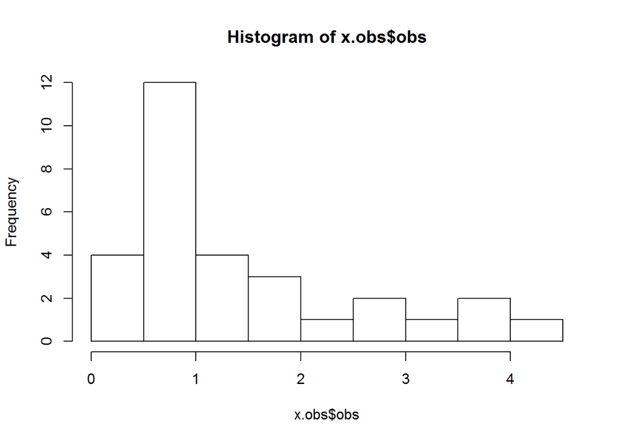

```r
hist(x.obs$obs)
```

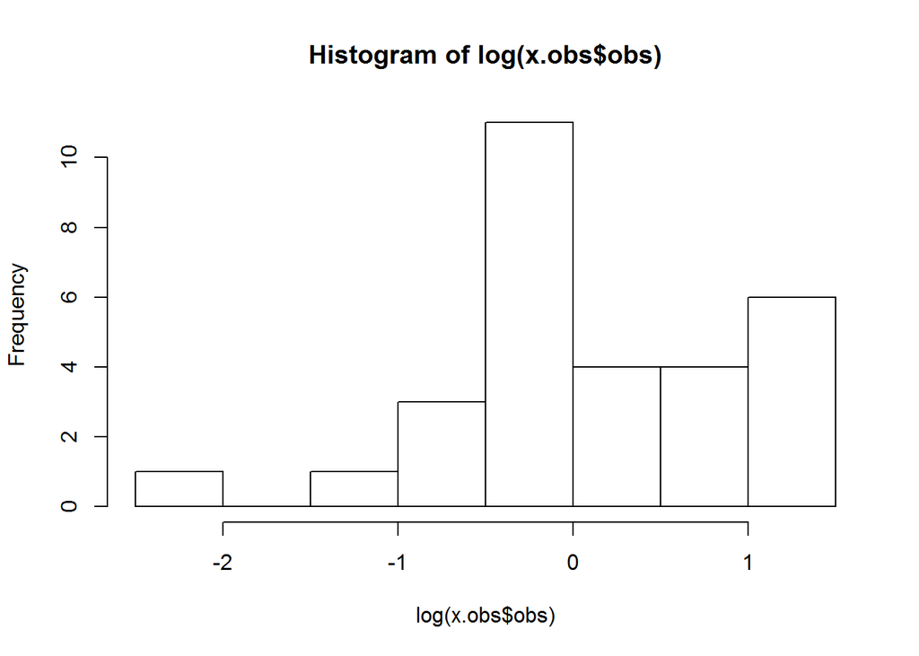

```r
hist(log(x.obs$obs))
```

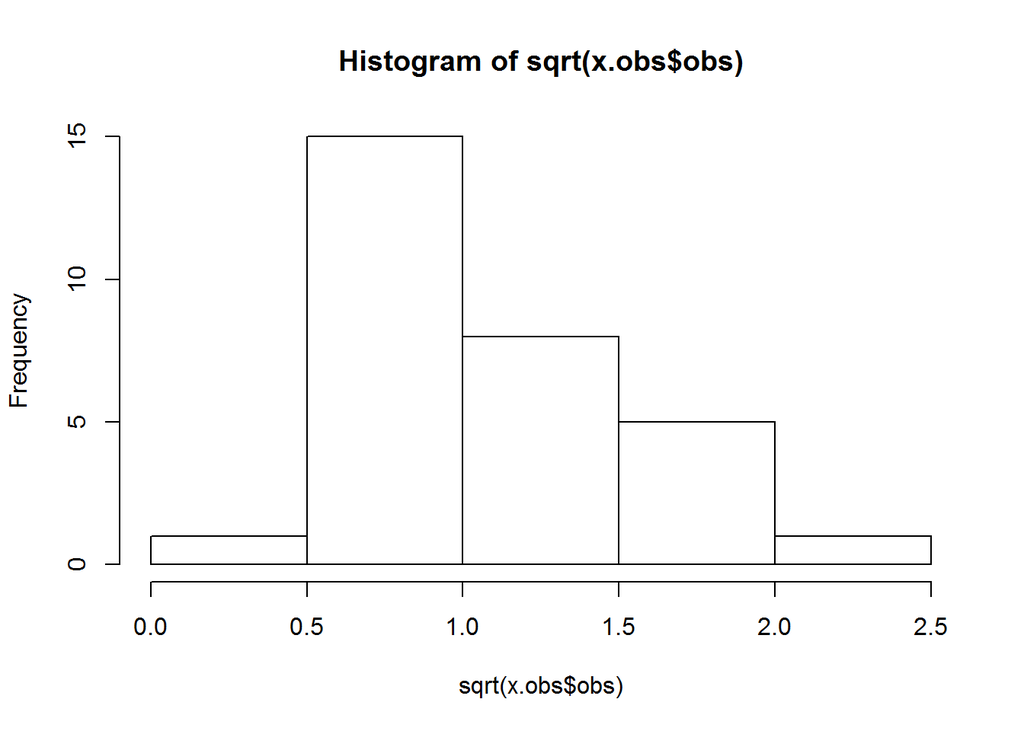

```r
hist(sqrt(x.obs$obs)) # best!
```

### Update rtopObj with transformed values

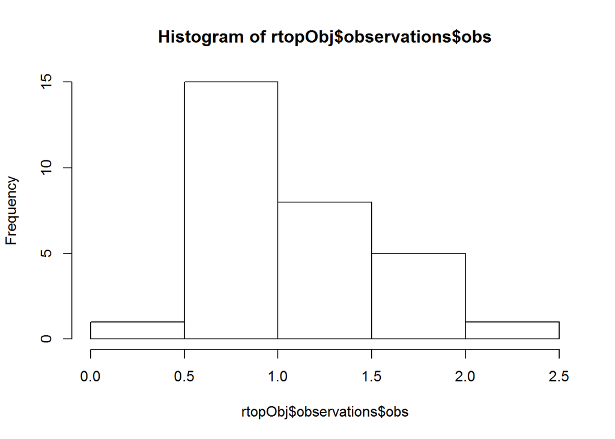

```r
x.obs$obs <- sqrt(x.obs$Q95S) # writing transfored obs in x.obs
x.obs$trans <- sqrt(x.obs$Q95S) # writing transfored obs in x.obs
x.pred$obs <- sqrt(x.pred$Q95S) # also in x.pred for ploting

observation <- x.obs[, "trans"]
prediction <- x.pred[, NULL]

top <- createRtopObject(
    observations = observation,
    predictionLocations = prediction,
    formulaString = "trans~1",
    params = params)

rtopObj <- createRtopObject(x.obs, x.pred, params = params) ## maybe include: formulaString=(obs)^2~1
hist(rtopObj$observations$obs) # is now closer to Gaussian distribution
```

### Summary statistics

```r
summary(x.obs$obs)
```

```
##    Min. 1st Qu.  Median    Mean 3rd Qu.    Max.
##  0.3317  0.8077  0.9849  1.1190  1.3407  2.0298
```

### Plot data locations and values

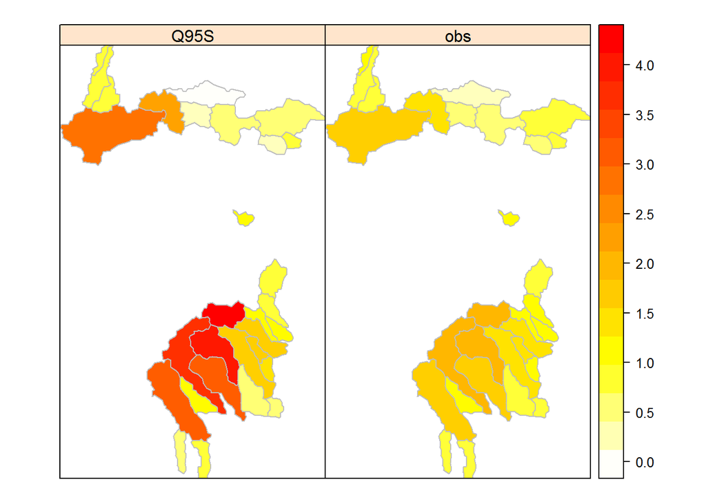

```r
spplot(
    obj = rtopObj$observations,
    zcol = c("Q95S", "obs"),
    col.regions = rev(heat.colors(n = 100)),
    col = "grey"
)
```

# Variogram model

A call to rtopVariogram adds the sample variogram to the object, whereas rtopFitVariogram fits a variogram model. The last function will call rtopVariogram if rtopObj does not contain a sample variogram.

### add the Sample variogram to the object

```r
rtopObj <- rtopVariogram(rtopObj)
top <- rtopVariogram(top)
```

### add the Theoretical variogram (various support) to the object

```r
rtopObj <- rtopFitVariogram(rtopObj)
```

```
## [1] "Sampling points from  30 areas"
## [1] "Sampled on average 218.4 points from 30 areas"
## 52 best 0.584 function convergence 200 parameter convergence 7008.858
## 80 best 0.494 function convergence 200 parameter convergence 4713.901
## 112 best 0.494 function convergence 200 parameter convergence 3334.488
## 147 best 0.487 function convergence 200 parameter convergence 2744.956
## 183 best 0.487 function convergence 200 parameter convergence 1915.205
## 213 best 0.486 function convergence 18.2 parameter convergence 1549.053
## 245 best 0.486 function convergence 1.62 parameter convergence 1394.539
## 278 best 0.486 function convergence 1.63 parameter convergence 1182.277
## 309 best 0.486 function convergence 0.0965 parameter convergence 938.3077
## 339 best 0.486 function convergence 0.102 parameter convergence 700.6196
## 372 best 0.486 function convergence 0.036 parameter convergence 441.736
## 402 best 0.486 function convergence 0.0394 parameter convergence 358.5353
## 428 best 0.486 function convergence 0.0337 parameter convergence 294.057
```

[output cut: 32 more lines]

```r
top <- rtopFitVariogram(top)
```

```
## [1] "Sampling points from  30 areas"
## [1] "Sampled on average 218.4 points from 30 areas"
## 52 best 0.513 function convergence 200 parameter convergence 6696.832
## 82 best 0.513 function convergence 200 parameter convergence 4240.94
## 111 best 0.496 function convergence 200 parameter convergence 3203.326
## 141 best 0.496 function convergence 200 parameter convergence 2588.874
## 174 best 0.495 function convergence 200 parameter convergence 1778.865
## 207 best 0.494 function convergence 3.68 parameter convergence 1396.624
## 233 best 0.492 function convergence 4.1 parameter convergence 928.9881
## 259 best 0.492 function convergence 0.905 parameter convergence 785.2561
## 287 best 0.491 function convergence 0.968 parameter convergence 716.4051
## 314 best 0.491 function convergence 0.863 parameter convergence 609.8957
## 342 best 0.49 function convergence 0.797 parameter convergence 457.6481
## 369 best 0.49 function convergence 0.416 parameter convergence 379.4876
## 396 best 0.49 function convergence 0.368 parameter convergence 340.8842
```

[output cut: 42 more lines]

The function checkVario is useful to produce some diagnostic plots for the sample variogram and the fitted variogram model.

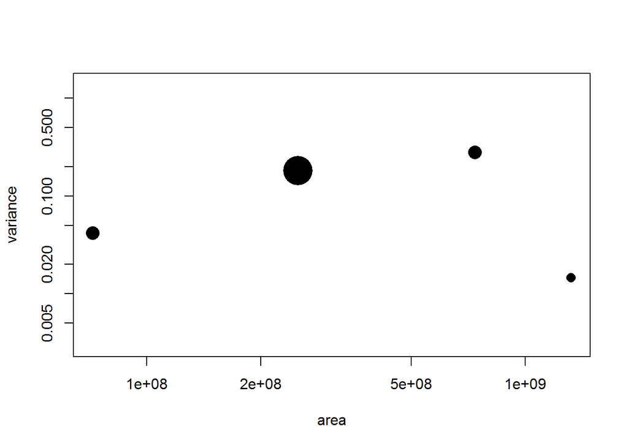

```
## [1] "cloud is  FALSE"
## [1] "Creating cloud variogram; this might take some time"
```

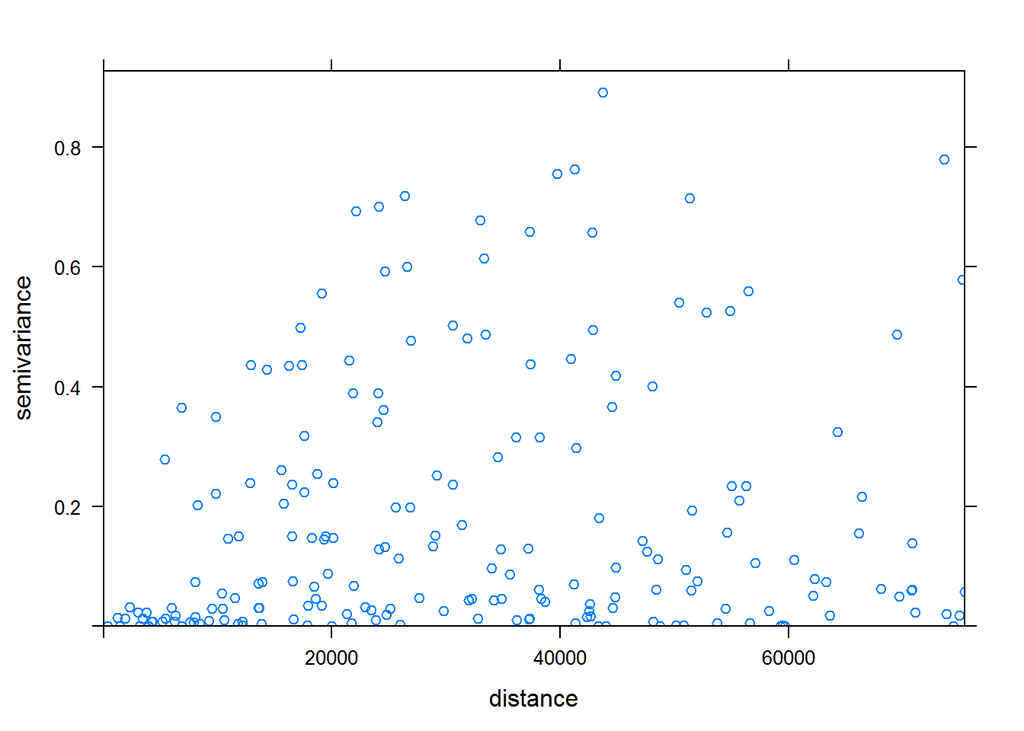

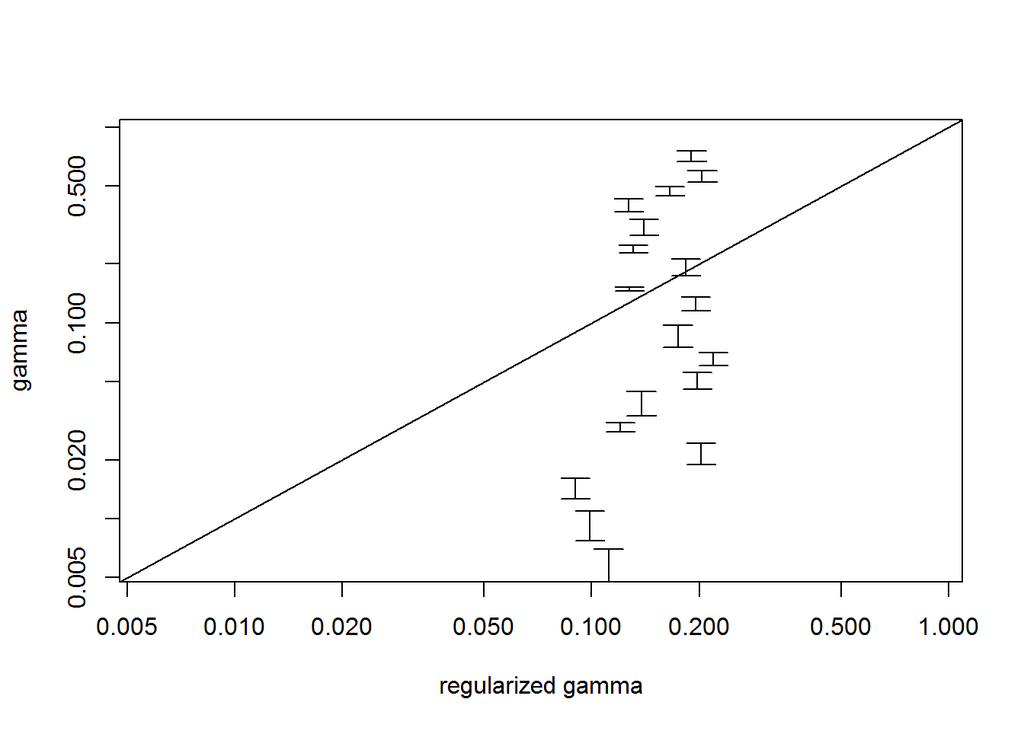

```
## [1] "Sampling points from  8 areas"
## [1] "Sampled on average 111.12 points from 8 areas"
## [1] "Sampling points from  8 areas"
## [1] "Sampled on average 114.5 points from 8 areas"
## [1] "Sampling points from  8 areas"
## [1] "Sampled on average 192.5 points from 8 areas"
## [1] "Sampling points from  7 areas"
## [1] "Sampled on average 101.43 points from 7 areas"
## [1] "Sampling points from  8 areas"
## [1] "Sampled on average 102.5 points from 8 areas"
```

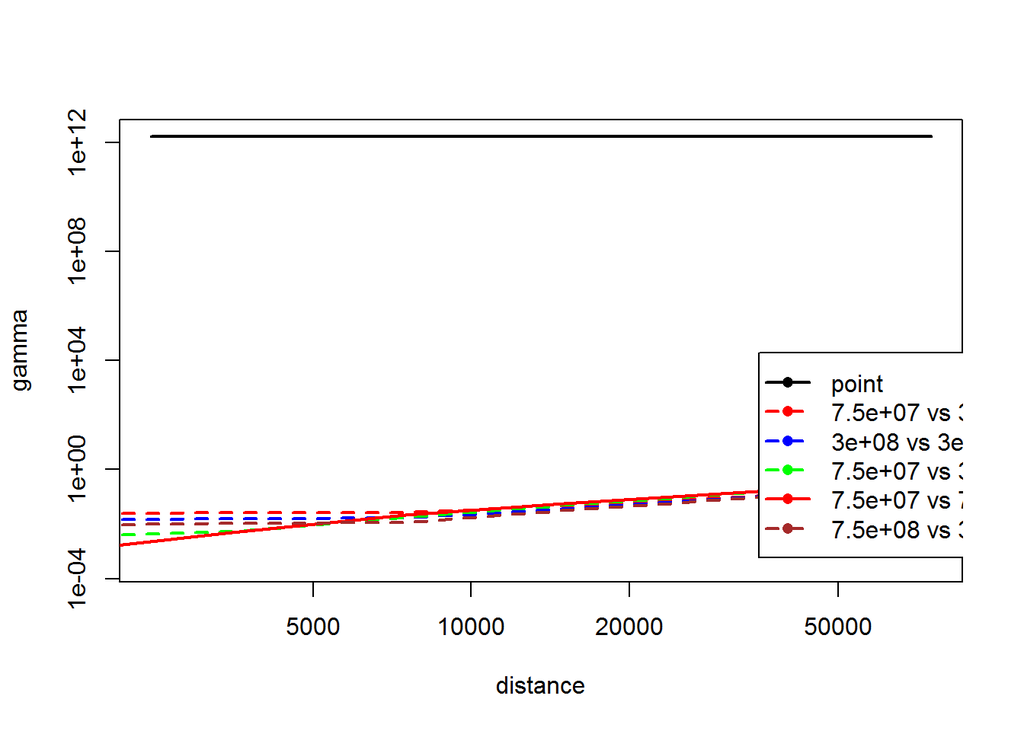

```r
checkVario(rtopObj)
```

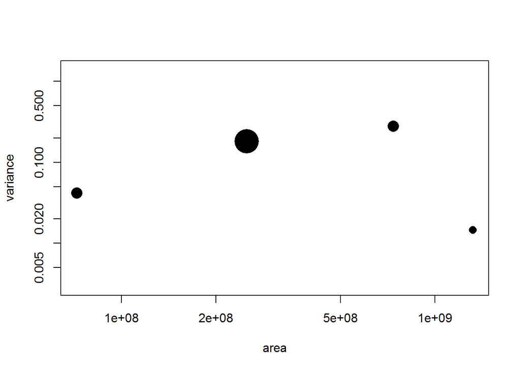

```
## [1] "cloud is  FALSE"
## [1] "Creating cloud variogram; this might take some time"
```

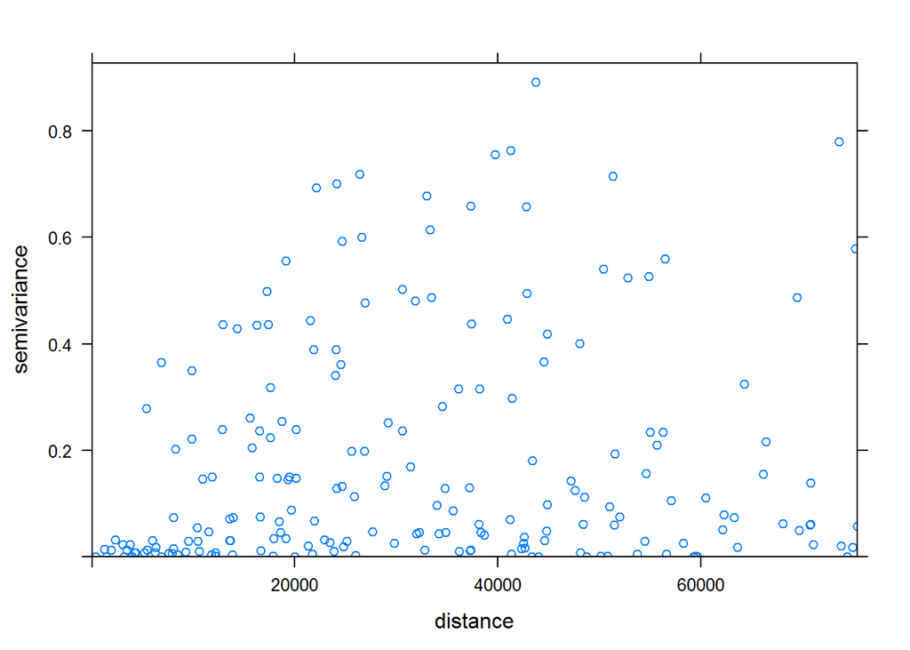

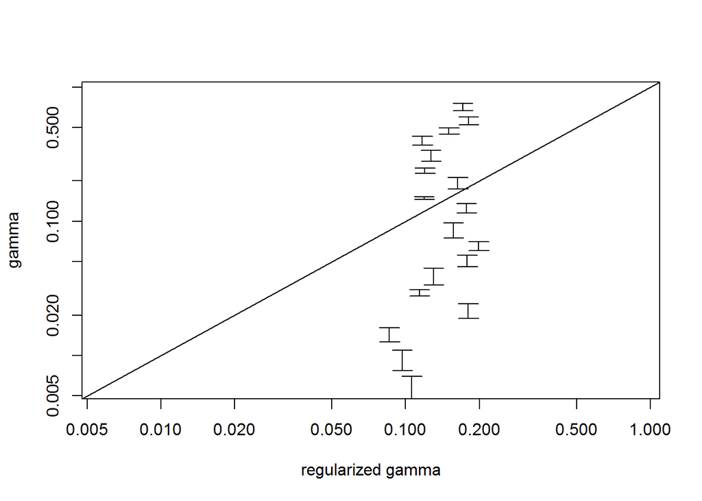

```
## [1] "Sampling points from  8 areas"
## [1] "Sampled on average 111.12 points from 8 areas"
## [1] "Sampling points from  8 areas"
## [1] "Sampled on average 247.12 points from 8 areas"
## [1] "Sampling points from  7 areas"
## [1] "Sampled on average 102.86 points from 7 areas"
## [1] "Sampling points from  8 areas"
## [1] "Sampled on average 102.5 points from 8 areas"
## [1] "Sampling points from  8 areas"
## [1] "Sampled on average 244.5 points from 8 areas"
```

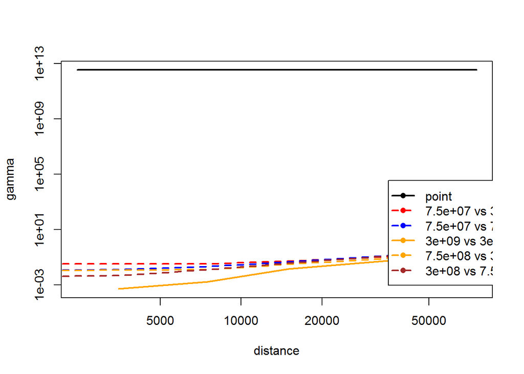

```r
checkVario(top)
```

# Kriging

The interpolation function (rtopKrige) solves the kriging system based on the computed regularized semivariances. The covariance matrices are created in a separate regularization function (varMat), and are stored in the rtop-object for easier access if it is necessary to redo parts of the analysis, as this is the computationally expensive part of the interpolation. Cross-validation can be called with the argument cv=TRUE, either in params or in the call to rtopKrige.

```r
rtopObj <- rtopKrige(rtopObj)
```

```
## [1] "Sampling points from  403 areas"
## [1] "Sampled on average 210.73 points from 403 areas"
## [1] "Creating prediction semivariance matrix. This can take some time."
## [1] "interpolating  403 areas"
```

```r
top <- rtopKrige(top)
```

```
## [1] "Sampling points from  403 areas"
## [1] "Sampled on average 210.73 points from 403 areas"
## [1] "Creating prediction semivariance matrix. This can take some time."
## [1] "interpolating  403 areas"
```

```r
names(rtopObj$predictions)
```

```
##  [1] "JUNCTIONID" "EZGID"      "SHAPE_AREA" "AREASQKM"   "AREA_KOR"
##  [6] "ID"         "Area_neu"   "Area_eff"   "OID_"       "HYDROID"
## [11] "HZBNR"      "AREASQKM_1" "AREA_KOR_1" "OID_1"      "HZBNR_1"
## [16] "X_LB"       "Y_LB"       "ICATCH"     "HORA_NR"    "AREA"
## [21] "XSTAT"      "YSTAT"      "XC"         "YC"         "YEARS"
## [26] "Q95"        "Q95S"       "OID1"       "TOJCT"      "SEL_BIG"
## [31] "OID1_1"     "TOJCT_1"    "SEL_BIG2"   "OID_12"     "TOJCT_12"
## [36] "SEL_BIG3"   "obs"        "area"       "var1.pred"  "var1.var"
## [41] "sumWeights"
```

```r
names(top$predictions)
```

```
## [1] "area"       "var1.pred"  "var1.var"   "sumWeights"
```

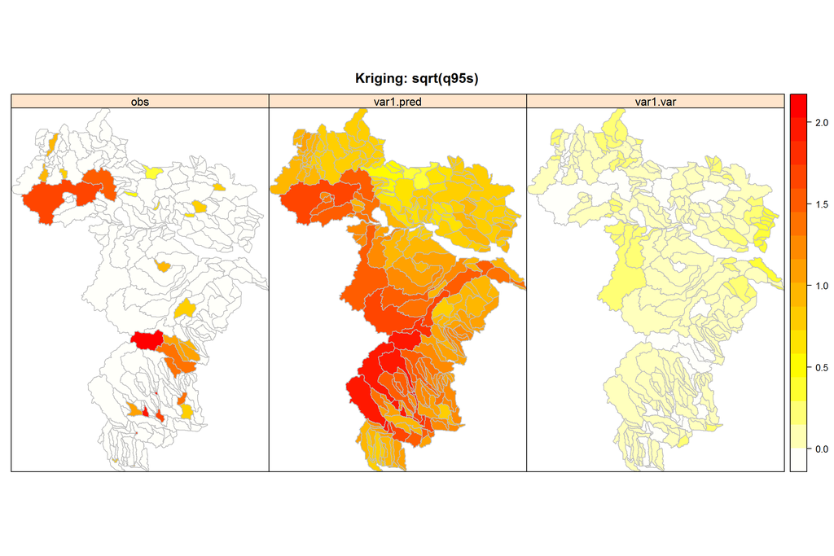

```r
spplot(
    obj = rtopObj$predictions, col.regions = rev(heat.colors(n = 100)), col = "grey",
    main = "Kriging: sqrt(q95s)",
    c("obs", "var1.pred", "var1.var")
)
```

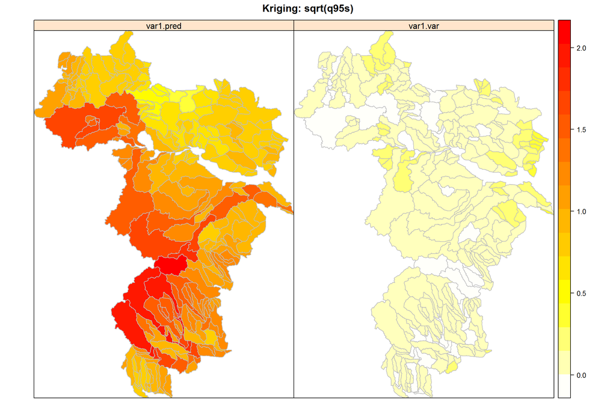

```r
spplot(
    obj = top$predictions, col.regions = rev(heat.colors(n = 100)), col = "grey",
    main = "Kriging: sqrt(q95s)",
    c("var1.pred", "var1.var")
)
```

# Cross-validation

```r
rtopObj <- rtopKrige(rtopObj, cv = TRUE)
```

```
## [1] "cross-validating 30 areas"
```

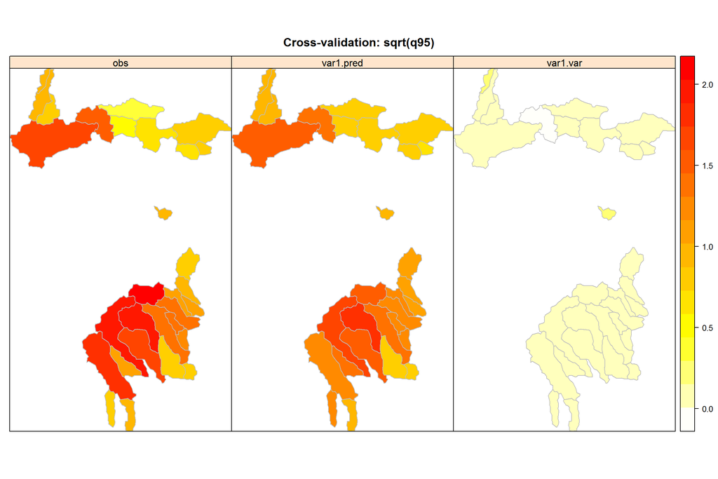

```r
spplot(
    obj = rtopObj$predictions, col.regions = rev(heat.colors(n = 100)), col = "grey",
    main = "Cross-validation: sqrt(q95)",
    c("obs", "var1.pred", "var1.var")
)
```

Some cv-performance measures

```r
cv_summary <- function(pred, obs) {
    res <- pred - obs
    ss <- sum(res^2)
    # mse <- var(res) # NO! gives only random errors without bias
    mse <- ss / length(res)
    rmse <- sqrt(mse)
    R2 <- 1 - (mse / var(obs))
    bias <- mean(res)
    return(list("RMSE" = rmse, "BIAS" = bias, "R²" = R2))
}
```

CV-performance of transformed Q95S (sqrt)

```r
cv_summary(pred = rtopObj$predictions$var1.pred, obs = rtopObj$predictions$obs)
```

```
## $RMSE
## [1] 0.2344216
##
## $BIAS
## [1] 0.02610078
##
## $R²
## [1] 0.7259941
```

CV-performance of backtransformed Q95S (^2)

```r
cv_summary(pred = rtopObj$predictions$var1.pred^2, obs = rtopObj$predictions$obs^2)
```

```
## $RMSE
## [1] 0.6030342
##
## $BIAS
## [1] -0.04135708
##
## $R²
## [1] 0.7159405
```

# References

- Laaha, G. & Blöschl, G. (2006) Seasonality indices for regionalizing low flows. Hydrological Processes 20(18), 3851-3878. doi:10.1002/hyp.6161
- Laaha, G., Skøien, J.O., Nobilis, F. & Blöschl, G. (2013) Spatial Prediction of Stream Temperatures Using Top-Kriging with an External Drift. Environmental Modeling & Assessment 18(6), 671-683. doi:10.1007/s10666-013-9373-3
- Laaha, G., Skøien, J.O. & Blöschl, G. (2014) Spatial prediction on river networks: comparison of top-kriging with regional regression. Hydrological Processes 28(2), 315-324.
- Skøien, J.O., Merz, R. & Blöschl, G. (2006). Top-kriging - geostatistics on stream networks. Hydrology and Earth System Sciences, 10:277-287.
- Skøien, J.O., Blöschl, G., Laaha, G., Pebesma, E., Parajka, J. & Viglione, A. (2014). Rtop: An R package for interpolation of data with a variable spatial support, with an example from river networks. Computers & Geosciences, 67.